# week2 - Dataanalysis

2025-10-11

#1 Data Analysis ## question 1. The following data contains the lengths of snapper1 from the Hauraki Gulf in centimetres. (a) Copy and paste this data into R. Do NOT type it in yourself. fish = c(73.88, 49.24, 38.63, 42.71, 33.36, 59.68, 57.27, 36.86, 59.93, 70.21, 52.86, 47.28, 38.17, 72.27, 33.62, 55.57, 57.59, 66.18, 46.67, 75.72, 48.88, 61.81, 45.97, 59.99, 57.20, 37.50, 48.32, 89.96, 56.52, 31.90, 36.00, 70.52, 50.23, 63.35, 55.44, 60.59, 53.75, 45.11, 55.89, 14.17, 42.99, 63.18, 35.71, 60.33, 73.51, 62.29, 33.22, 33.63, 39.77, 50.10, 31.64, 43.83, 20.01, 60.02, 42.83, 61.72, 7.13, 47.30, 36.40, 50.96, 79.43, 51.49, 62.68, 39.45, 61.05, 63.71, 37.07, 60.28, 57.60, 25.73, 43.71, 53.12, 59.01, 50.66, 46.63, 59.19, 58.80, 66.83, 39.27, 43.72, 58.81, 56.67, 52.80, 73.57, 62.87, 39.48, 42.64, 27.04, 25.15, 38.51, 38.34, 55.12, 86.48, 31.82, 49.17, 41.99, 50.10, 56.84, 44.04, 48.30)

```r
fish = c(73.88, 49.24, 38.63, 42.71, 33.36, 59.68, 57.27, 36.86, 59.93,
70.21, 52.86, 47.28, 38.17, 72.27, 33.62, 55.57, 57.59, 66.18, 46.67,
75.72, 48.88, 61.81, 45.97, 59.99, 57.20, 37.50, 48.32, 89.96, 56.52,
31.90, 36.00, 70.52, 50.23, 63.35, 55.44, 60.59, 53.75, 45.11, 55.89,
14.17, 42.99, 63.18, 35.71, 60.33, 73.51, 62.29, 33.22, 33.63, 39.77,
50.10, 31.64, 43.83, 20.01, 60.02, 42.83, 61.72, 7.13, 47.30, 36.40,
50.96, 79.43, 51.49, 62.68, 39.45, 61.05, 63.71, 37.07, 60.28, 57.60,
25.73, 43.71, 53.12, 59.01, 50.66, 46.63, 59.19, 58.80, 66.83, 39.27,
43.72, 58.81, 56.67, 52.80, 73.57, 62.87, 39.48, 42.64, 27.04, 25.15,
38.51, 38.34, 55.12, 86.48, 31.82, 49.17, 41.99, 50.10, 56.84, 44.04,
48.30)
```

How many snapper lengths are represented in the dataset? (Hint: use length(x))

```r
length(fish)
```

```
## [1] 100
```

What type/s of graph would be appropriate for representing this data? Discuss.

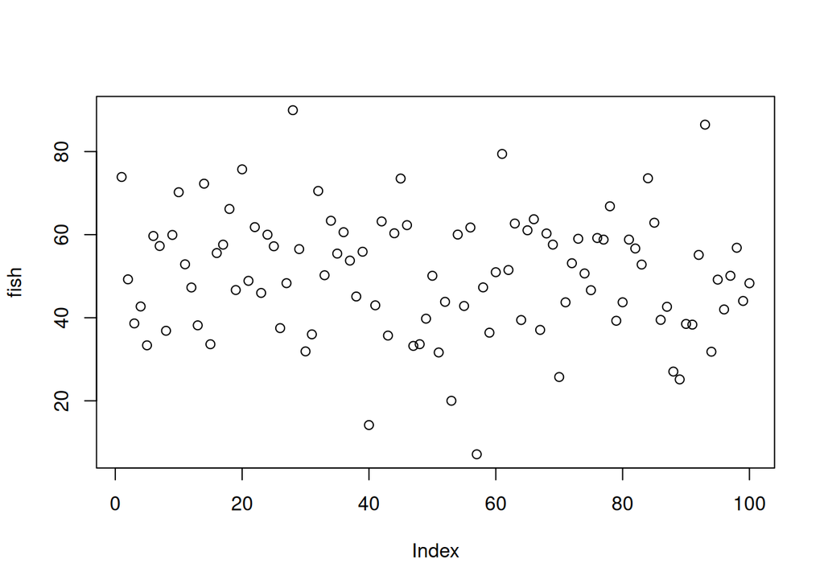

```r
plot(fish)
```

When plotting the fish, we do not see any correlation as the plots are scattered.

plot(fish)

```
Next lets try to print the table to check the count of records for each length
```

```r
table(fish)
```

```
## fish
##  7.13 14.17 20.01 25.15 25.73 27.04 31.64 31.82  31.9 33.22 33.36 33.62 33.63
##     1     1     1     1     1     1     1     1     1     1     1     1     1
## 35.71    36  36.4 36.86 37.07  37.5 38.17 38.34 38.51 38.63 39.27 39.45 39.48
##     1     1     1     1     1     1     1     1     1     1     1     1     1
## 39.77 41.99 42.64 42.71 42.83 42.99 43.71 43.72 43.83 44.04 45.11 45.97 46.63
##     1     1     1     1     1     1     1     1     1     1     1     1     1
## 46.67 47.28  47.3  48.3 48.32 48.88 49.17 49.24  50.1 50.23 50.66 50.96 51.49
##     1     1     1     1     1     1     1     1     2     1     1     1     1
##  52.8 52.86 53.12 53.75 55.12 55.44 55.57 55.89 56.52 56.67 56.84  57.2 57.27
##     1     1     1     1     1     1     1     1     1     1     1     1     1
## 57.59  57.6  58.8 58.81 59.01 59.19 59.68 59.93 59.99 60.02 60.28 60.33 60.59
##     1     1     1     1     1     1     1     1     1     1     1     1     1
## 61.05 61.72 61.81 62.29 62.68 62.87 63.18 63.35 63.71 66.18 66.83 70.21 70.52
##     1     1     1     1     1     1     1     1     1     1     1     1     1
## 72.27 73.51 73.57 73.88 75.72 79.43 86.48 89.96
##     1     1     1     1     1     1     1     1
```

Next lets plot the histogram and to verify it manually lets sort the data to check the frequency roughly

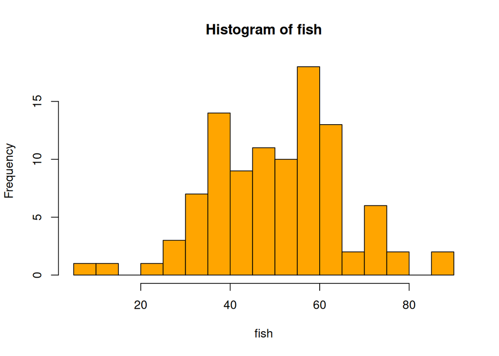

```r
hist(fish,col = "orange", breaks = 20 )
```

```r
sort(fish)
```

```
##   [1]  7.13 14.17 20.01 25.15 25.73 27.04 31.64 31.82 31.90 33.22 33.36 33.62
##  [13] 33.63 35.71 36.00 36.40 36.86 37.07 37.50 38.17 38.34 38.51 38.63 39.27
##  [25] 39.45 39.48 39.77 41.99 42.64 42.71 42.83 42.99 43.71 43.72 43.83 44.04
##  [37] 45.11 45.97 46.63 46.67 47.28 47.30 48.30 48.32 48.88 49.17 49.24 50.10
##  [49] 50.10 50.23 50.66 50.96 51.49 52.80 52.86 53.12 53.75 55.12 55.44 55.57
##  [61] 55.89 56.52 56.67 56.84 57.20 57.27 57.59 57.60 58.80 58.81 59.01 59.19
##  [73] 59.68 59.93 59.99 60.02 60.28 60.33 60.59 61.05 61.72 61.81 62.29 62.68
##  [85] 62.87 63.18 63.35 63.71 66.18 66.83 70.21 70.52 72.27 73.51 73.57 73.88
##  [97] 75.72 79.43 86.48 89.96
```

```r
table(fish)
```

```
## fish
##  7.13 14.17 20.01 25.15 25.73 27.04 31.64 31.82  31.9 33.22 33.36 33.62 33.63
##     1     1     1     1     1     1     1     1     1     1     1     1     1
## 35.71    36  36.4 36.86 37.07  37.5 38.17 38.34 38.51 38.63 39.27 39.45 39.48
##     1     1     1     1     1     1     1     1     1     1     1     1     1
## 39.77 41.99 42.64 42.71 42.83 42.99 43.71 43.72 43.83 44.04 45.11 45.97 46.63
##     1     1     1     1     1     1     1     1     1     1     1     1     1
## 46.67 47.28  47.3  48.3 48.32 48.88 49.17 49.24  50.1 50.23 50.66 50.96 51.49
##     1     1     1     1     1     1     1     1     2     1     1     1     1
##  52.8 52.86 53.12 53.75 55.12 55.44 55.57 55.89 56.52 56.67 56.84  57.2 57.27
##     1     1     1     1     1     1     1     1     1     1     1     1     1
## 57.59  57.6  58.8 58.81 59.01 59.19 59.68 59.93 59.99 60.02 60.28 60.33 60.59
##     1     1     1     1     1     1     1     1     1     1     1     1     1
## 61.05 61.72 61.81 62.29 62.68 62.87 63.18 63.35 63.71 66.18 66.83 70.21 70.52
##     1     1     1     1     1     1     1     1     1     1     1     1     1
## 72.27 73.51 73.57 73.88 75.72 79.43 86.48 89.96
##     1     1     1     1     1     1     1     1
```

[output not shown]

[output not shown]

Lets calcualte InterQuartile Range and then print the lower and upper range

```r
IQR_val <- IQR(fish)
IQR_val
```

```
## [1] 20.525
```

```r
quantiles[[1]]-1.5*IQR_val
```

```
## [1] 8.685
```

```r
quantiles[[3]] + 1.5*IQR_val
```

```
## [1] 90.785
```

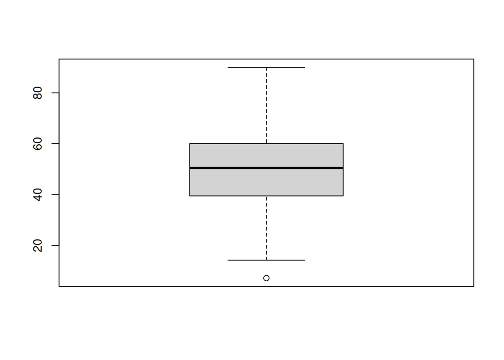

```r
boxplot(fish)
```